# How life expectancy change over time for each continent?

Life expectancy for a country is the mean length of life over people of a country. Using variables life expectancy and population of a country:

1. derive a formula to compute life expectancy of a continent (a group of countries)
2. plot how life expectancy changed over time for each continent
3. do the same for the whole planet

## Our solution

### 1.

The life expectancy of a continent in a given year is the mean of the life expectancies of its countries, weighted by population: a populous country counts more because it contains more people.

$$LE_{C,y} = \frac{\sum_{c \ \in \ C} LE_{c,y}\cdot pop_{c,y}}{\sum_{c \
\in \ C} pop_{c,y}} \qquad y = year, c = country, C = continent$$

```r
library(gapminder)
library(dplyr)
library(ggplot2)

gap_y <- gapminder |>
  group_by(continent, year) |>
  summarise(
    pop_tot_y = sum(pop),
    lifeExpC_y = sum(lifeExp * pop) / pop_tot_y
  )

gap_y |>
  select(-pop_tot_y)
```

```
## # A tibble: 60 × 3
## # Groups:   continent [5]
##    continent  year lifeExpC_y
##    <fct>     <int>      <dbl>
##  1 Africa     1952       38.8
##  2 Africa     1957       40.9
##  3 Africa     1962       43.1
##  4 Africa     1967       45.2
##  5 Africa     1972       47.2
##  6 Africa     1977       49.2
##  7 Africa     1982       51.0
##  8 Africa     1987       52.8
##  9 Africa     1992       53.4
## 10 Africa     1997       53.3
## # ℹ 50 more rows
```

### 2.

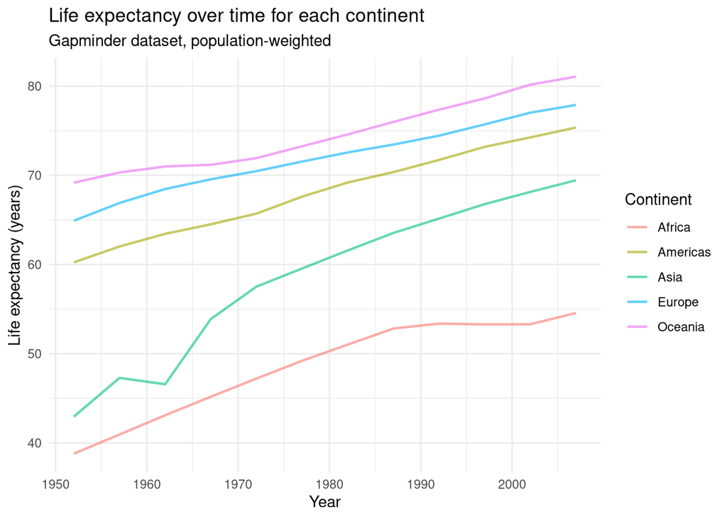

```r
gap_y |>
  ggplot(aes(x = year, y = lifeExpC_y, group = continent, color = continent)) +
  geom_line(alpha = 0.6, linewidth = 0.8) +
  labs(
    title = "Life expectancy over time for each continent",
    subtitle = "Gapminder dataset, population-weighted",
    x = "Year",
    y = "Life expectancy (years)",
    color = "Continent"
  ) +
  theme_minimal()
```

All continents gain years of life over time, but with different speeds. Oceania and Europe start high (69 and 65 years in 1952) and reach 81 and 78 in 2007. Asia is the one that grows the most, from 43 to 69 years (+26), and it closes most of the gap with the Americas (from 60 to 75). Africa starts lowest (39 years) and ends lowest (55), and its growth slows down after the 1980s. The gap between the best and the worst continent is about 30 years in 1952 and still about 27 in 2007.

### 3.

The same formula applies to the whole planet: group all countries together.

$$LE_{y} = \frac{\sum_{c} LE_{c,y}\cdot pop_{c,y}}{\sum_{c} pop_{c,y}}$$

```r
gap_p_y <- gapminder |>
  group_by(year) |>
  summarise(
    pop_tot_p_y = sum(pop),
    lifeExp_p_y = sum(lifeExp * pop) / pop_tot_p_y
  )

gap_p_y |>
  select(-pop_tot_p_y)
```

```
## # A tibble: 12 × 2
##     year lifeExp_p_y
##    <int>       <dbl>
##  1  1952        48.9
##  2  1957        52.1
##  3  1962        52.3
##  4  1967        57.0
##  5  1972        59.5
##  6  1977        61.2
##  7  1982        62.9
##  8  1987        64.4
##  9  1992        65.6
## 10  1997        66.8
## 11  2002        67.8
## 12  2007        68.9
```

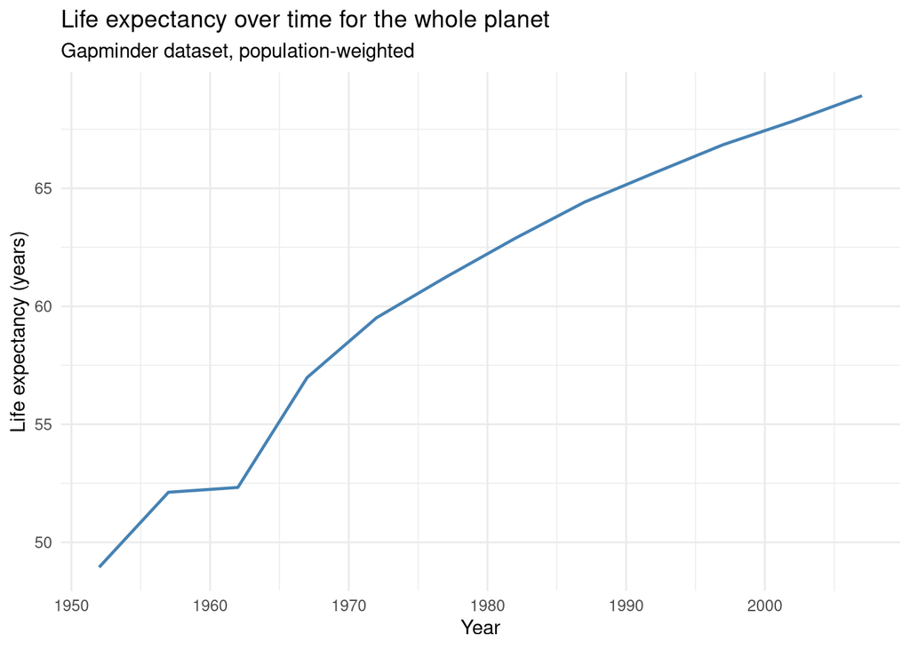

```r
gap_p_y |>
  ggplot(aes(x = year, y = lifeExp_p_y)) +
  geom_line(color = "steelblue", linewidth = 0.8) +
  labs(
    title = "Life expectancy over time for the whole planet",
    subtitle = "Gapminder dataset, population-weighted",
    x = "Year",
    y = "Life expectancy (years)"
  ) +
  theme_minimal()
```